# Cell-type perturbation in MASH vs healthy liver

Author

Richard Ahn, PhD

```r
suppressPackageStartupMessages({
  library(Seurat)
  library(Matrix)
  library(dplyr)
  library(tidyr)
  library(ggplot2)
  library(patchwork)
  library(speckle)     # propeller: donor-level differential abundance
  library(DESeq2)      # pseudobulk differential expression
  library(fgsea)       # GSEA on the ranked DE statistics
  library(msigdbr)     # MSigDB Hallmark gene sets
  library(knitr)
})

set.seed(1234)

# Format p-values for inline prose. signif() alone yields values like 1.3e-07,
# which the inline hook renders as broken superscript markup.
fmt_p <- function(x) {
  x <- unname(x[1])
  if (is.na(x)) return("NA")
  if (x < 1e-3) formatC(x, format = "e", digits = 1) else formatC(signif(x, 2), format = "g")
}

CACHE_DIR <- "cache"
dir.create(CACHE_DIR, showWarnings = FALSE, recursive = TRUE)
cache_path <- function(name) file.path(CACHE_DIR, name)

# Compute-or-load guard. Expensive steps that touch the full object write a
# small intermediate to cache/ and reuse it on later renders. Deleting cache/
# forces a full cold run, so the document stays reproducible from the raw data.
cached <- function(name, expr) {
  p <- cache_path(name)
  if (file.exists(p)) return(readRDS(p))
  x <- force(expr)
  saveRDS(x, p)
  x
}

# COL1A1 counts for every nucleus, needed in two separate sections. Wrapped in a
# function so neither section depends on the other having run first.
col1a1_counts <- function() cached("col1a1_distribution.rds", {
  library(BPCells)
  as.vector(as.matrix(open_matrix_dir("bpcells_counts")["COL1A1", ]))
})
```

## Introduction

The prompt is to take a MASH scRNA-seq or snRNA-seq dataset and highlight which cell types are most perturbed and how relative to healthy liver. I think “most perturbed” carries two distinct meanings:

1. **Differential abundance.** Which cell types change in proportion between MASH and control. A cell type can be strongly perturbed here while its surviving cells look transcriptionally ordinary.
2. **Within-cell-type differential expression.** How the cells of a given type are transcriptionally rewired in disease. A cell type can hold steady in proportion while its program shifts substantially.

These are measured separately below and only combined at the end, in a ranked table that answers the prompt on both axes.

The cohort is staged rather than binary: healthy control, isolated steatosis (MASL), early MASH and advanced MASH. The primary comparison is the clean case-control contrast of control against MASH, with MASL held out so that cases with steatosis but no steatohepatitis do not dilute it. MASL is then put back to work in two secondary views: an ordered trend across all four stages, and stage-adjacent contrasts that localize where along the progression each cell type actually changes. A cell type that shifts only between early and advanced MASH is telling a different story from one that shifts at the onset of steatosis, and the two-group contrast alone cannot distinguish them.

I made the decision to run **analyses at the donor level, not the cell level.** A dataset of a quarter of a million nuclei from 48 people now carries 48 independent observations, not 250,000. Abundance is therefore tested on donor-level proportions, and expression on donor-level pseudobulk.

I used Claude Code Opus 5 for this report.

## Executive summary

**Hepatocytes are the most perturbed cell type, and the only one perturbed on both axes.** They lose more than half their share of nuclei across the progression from control to MASH, and those nuclei carry more differentially expressed genes than any other cell type by a wide margin. The program is coherent: p53 and growth arrest up, differentiated metabolic function down, with bile acid, xenobiotic and fatty acid metabolism all depleted. The compositional result independently reproduces the source paper’s headline.

**Endothelial cells do not change in abundance at all**, yet carry the second-largest expression program in the dataset, and its content is inflammatory activation. T cells expand several-fold in number while changing their expression program comparatively little.

**Macrophages change identity rather than number,** switching from the resident Kupffer program to a lipid-handling, scar-associated one. This is the most mechanistically specific result here, and it reproduces the macrophage arm of the fibrotic niche described in cirrhosis by Ramachandran et al., in a cohort that has not reached cirrhosis.

**Two results required correcting the deposited annotation rather than trusting it.** A subcluster labeled as inactivated stellate cells is vascular mural tissue, which inverts the apparent direction of the stellate contractile program when the label is aggregated. And stellate abundance appears unchanged in the two-group contrast because it is not monotonic: the compartment expands only at advanced fibrosis, which a control-versus-MASH comparison cancels out.

**What this dataset cannot answer.** It does not contain collagen-producing myofibroblasts, and two of the three scar-associated populations from the reference cirrhosis atlas are absent while the one not embedded in scar replicates cleanly. I think the explanation is that needle-core biopsy tissue does not recover cells resident in dense matrix. The consequence is nothing here bears on myofibroblast biology in either direction, and the flat collagen result is a sampling limit rather than evidence against fibrogenesis.

**Implications for therapeutics are limited to target engageability.** The receptors for thyromimetic, FXR and PPAR-alpha agonism are well expressed in the cell types those drugs act on, and the programs they regulate are among the things disease has disturbed. GLP-1 and GIP receptors are not expressed in this tissue, so a liver atlas is the wrong instrument for those agents. However, the glucagon arm of a dual agonist is the exception, with a direct and measurable hepatocyte target. Anti-fibrotic targets cannot be assessed, for the sampling reason above. None of this speaks to potential efficacy.

## Data provenance

Single-nucleus RNA-seq of 48 human liver biopsies spanning the MASLD spectrum, from Hong et al., *Nature Genetics* 2025. Raw data are deposited under GEO GSE289173 (BioProject PRJNA1221860); the processed Seurat object analyzed here is distributed via Zenodo (10.5281/zenodo.14586466, CC-BY 4.0).

### Why this dataset

Several candidate datasets were considered before settling on this one (see table below). I chose the Hong et al. dataset because it is snRNA-seq, includes MASH and control samples from human liver biopsies, has a sufficient number of donors and nuclei, and, decisively, because its processed data was verified as downloadable rather than merely deposited.

| # | Dataset (accession) | Human | Liver biopsy | Indication | sc / sn | Atlas | Download verified? |
| --- | --- | --- | --- | --- | --- | --- | --- |
| 1 | sc-eQTL MASH, Hong 2025 (GSE289173 / Zenodo 14586466) | Yes | Yes | MASH + control | sn | No (cohort) | **Yes — processed Seurat v4 on Zenodo, CC-BY, 6.6 GB, opened and confirmed** |
| 2 | EphB2 NASH transition, Xiao 2023 (GSE189600) | Yes (+ mouse) | Yes | NAFL→NASH | sn (+ snATAC) | No | Strongly — independently re-downloaded from GEO by ≥3 later papers |
| 3 | Spatial multi-omics MASLD atlas, NatGen 2025 (s41588-025-02407-8) | Yes | Yes | control / MASL / MASH | both | Yes | Not yet — accession not confirmed |
| 4 | Human HSC multi-omics, J Hepatol 2024 (S0168-8278(24)02667-9) | Yes | Yes | normal / MASL / MASH | sn (+ snATAC) | No (HSC-only) | Not yet — accession not confirmed |
| 5 | Human snRNA-seq MASH (GSE212837) | Yes | Yes | MASH | sn | No | Deposited + reused; file listing not opened |
| 6 | Human scRNA-seq MASH (GSE189175) | Yes | Yes | MASH | sc | No | Deposited + reused; file listing not opened |
| — | Copenhagen NASH, Fred 2022 | Yes | Yes | NASH | sc | No | **Excluded — no raw data released, no healthy controls** |

The Hong et al. study is primarily a single-cell eQTL analysis, and its headline result is a hepatocyte maladaptation signal at *EFHD1*/*FOXO1*. The cell-type perturbation question asked here is described in that paper but not developed in depth, and its differential expression was run cell-level with Seurat `FindMarkers`. The contribution of this report is to answer the perturbation question directly, with donor-level replication on both axes.

The downloadable object was built with Cellranger, Cellbender for ambient RNA, DoubletFinder for doublets, Liger for integration and Seurat for clustering. Liger was not an arbitrary choice: the authors benchmarked it against FastMNN, Harmony, CCA and RPCA on kBET acceptance rate and selected it on that basis. Normalization was done with `scran` and `batchelor` rather than Seurat’s log-normalization. This analysis reuses that object and its integration as-is, and validates the annotations rather than re-deriving them.

### Cohort, contrasts and marker panels

The Zenodo deposit ships tidied metadata: seven columns, with disease stage already in current MASLD/MASH nomenclature rather than the pre-2023 NAFLD terms used in the authors’ analysis scripts. No remapping is needed.

Two annotation columns are supplied. `Cell_type_broad` gives 14 labels; `Cell_type_detailed` gives 19, and nests cleanly inside the broad column. Only two lineages subdivide, and both subdivide along exactly the axis MASH acts on: hepatocytes split by zonation, stellate cells by activation state. That is used below, after the primary analysis, to ask where within a lineage the perturbation sits.

```r
# Metadata columns, confirmed against the object rather than assumed.
COL_DONOR    <- "DonorID"
COL_STAGE    <- "Disease_group"
COL_CT_BROAD <- "Cell_type_broad"
COL_CT_FINE  <- "Cell_type_detailed"

# Disease stage, in the order of progression.
STAGE_LEVELS <- c("control", "MASL", "eMASH", "aMASH")
STAGE_LABELS <- c(control = "No-MASLD", MASL = "MASL",
                  eMASH = "eMASH", aMASH = "aMASH")

# Primary contrast is two-group. MASL is the intermediate stage and is held out
# of it, so the headline case-control comparison is not diluted by cases that
# have steatosis without steatohepatitis. MASL is not discarded: it carries the
# ordered trend analysis and the stage-adjacent contrasts defined below.
CONDITION_MAP <- c(control = "Control", MASL = NA,
                   eMASH = "MASH", aMASH = "MASH")
CONDITION_LEVELS <- c("Control", "MASH")

# Secondary stage-wise contrasts, run after the primary. Each is a step along
# the progression, which localizes where in the disease course a cell type
# changes rather than only whether it differs at the endpoint.
STAGE_CONTRASTS <- list(
  c("control", "MASL"),   # onset of steatosis
  c("MASL",    "eMASH"),  # steatosis to steatohepatitis
  c("control", "eMASH"),  # control to early MASH
  c("eMASH",   "aMASH"),  # early to advanced fibrosis
  c("control", "aMASH")   # full span, largest expected effect
)

# Thresholds for calling a gene differentially expressed. Significance alone
# admits very small effects when donor numbers are adequate, so an effect-size
# floor is applied alongside it. Both are stated wherever counts are reported.
FDR_CUTOFF <- 0.05
LFC_CUTOFF <- 0.25

# Applied to every DESeq2 result table in this report.
is_de <- function(r) {
  !is.na(r$padj) & r$padj < FDR_CUTOFF & abs(r$log2FoldChange) >= LFC_CUTOFF
}
DE_RULE <- paste0("FDR < ", FDR_CUTOFF, " and |log2FC| >= ", LFC_CUTOFF)

# Not cell types. Per the source paper's supplementary methods, "Unidentified"
# marks cells whose substate assignment disagreed between the joint and the
# disease-stratified subclustering. Excluded from every analysis below.
DROP_LABELS <- c("Suspected_doublet", "Unidentified")

# Canonical human liver markers, used to verify the shipped annotations before
# any claim is built on them.
LIVER_MARKERS <- list(
  Hepatocyte    = c("ALB", "APOA1", "TTR", "CYP2E1", "HNF4A", "ASGR1"),
  Cholangiocyte = c("KRT19", "KRT7", "EPCAM", "SOX9", "CFTR"),
  Stellate      = c("COL1A1", "COL3A1", "DCN", "PDGFRB", "RGS5"),
  Endothelial   = c("PECAM1", "VWF", "CLEC4G", "STAB2", "LYVE1"),
  Kupffer_Mac   = c("CD68", "MARCO", "VSIG4", "C1QA", "CD5L"),
  Scar_Mac      = c("TREM2", "CD9", "GPNMB", "SPP1", "LYZ"),
  T_cell        = c("CD3D", "CD3E", "CD8A", "IL7R"),
  NK            = c("NKG7", "GNLY", "KLRD1"),
  B_Plasma      = c("CD79A", "MS4A1", "MZB1", "IGHG1")
)

# programs the differential expression results are checked against. These are
# recovered from the data, not asserted; they exist here to make the check
# explicit rather than post hoc.
MASH_PROGRAMS <- list(
  HSC_activation      = c("COL1A1", "COL3A1", "ACTA2", "TIMP1", "TAGLN"),
  Scar_macrophage     = c("TREM2", "CD9", "GPNMB", "SPP1"),
  Kupffer_homeostatic = c("MARCO", "VSIG4", "CD5L", "CLEC4F"),
  LSEC_identity       = c("CLEC4G", "STAB2", "LYVE1", "OIT3"),
  Ductular_reaction   = c("KRT19", "KRT7", "SOX9", "EPCAM")
)
```

## Loading the object

The deposited object is Seurat v4 and occupies roughly 14 GB once loaded, which leaves no headroom on a 16 GB machine. That shapes the code below, especially the decision to run on-disk using BPCells.

Everything expensive runs once, writes a compact intermediate to `cache/`, and is reused afterwards. Counts are additionally written to an on-disk BPCells matrix, so per-cell-type aggregation streams from disk instead of holding a 24,615 x 249,233 sparse matrix in RAM. Deleting `cache/` and `bpcells_counts/` forces a full recomputation from the deposited file.

```r
RDS <- "data/unzipped/Zenodo/processed_seurat_object/MASLD_snRNA_seq_seurat_v4.rds"

if (!file.exists(cache_path("meta.rds")) || !dir.exists("bpcells_counts")) {
  library(BPCells)
  mem.maxVSize(vsize = 64000)          # allow the load to spill past physical RAM
  obj <- readRDS(RDS)
  rna <- obj@assays$RNA

  saveRDS(obj@meta.data, cache_path("meta.rds"))
  saveRDS(list(dim = dim(obj), reductions = names(obj@reductions),
               genes = rownames(rna), seurat_ver = as.character(obj@version)),
          cache_path("obj_info.rds"))
  for (rd in names(obj@reductions)) {
    e <- obj@reductions[[rd]]@cell.embeddings
    saveRDS(e[, 1:min(3, ncol(e))], cache_path(paste0("emb_", rd, ".rds")))
  }

  cnt <- rna@counts                     # raw integer counts, required for pseudobulk
  rm(obj, rna); gc()
  BPCells::write_matrix_dir(cnt, dir = "bpcells_counts", compress = TRUE)
  rm(cnt); gc()
}

md   <- readRDS(cache_path("meta.rds"))
info <- readRDS(cache_path("obj_info.rds"))

md$stage     <- factor(md[[COL_STAGE]], levels = STAGE_LEVELS,
                       labels = STAGE_LABELS[STAGE_LEVELS])
md$condition <- factor(unname(CONDITION_MAP[as.character(md[[COL_STAGE]])]),
                       levels = CONDITION_LEVELS)

# Technical labels are not cell types and are excluded from every analysis.
n_dropped <- sum(md[[COL_CT_BROAD]] %in% DROP_LABELS)
md <- md[!md[[COL_CT_BROAD]] %in% DROP_LABELS, ]
```

The object holds 249,233 nuclei and 24,615 genes, integrated with Liger (reductions: iNMF_raw, iNMF, umap). Dropping Suspected_doublet and Unidentified removes 9,323 nuclei, leaving 239,910 for analysis.

## Cohort

```r
donors <- unique(md[, c(COL_DONOR, "stage", "condition")])
names(donors)[1] <- "donor"

cohort <- as.data.frame(table(Stage = donors$stage), responseName = "Donors")
cohort$Nuclei <- as.integer(table(factor(md$stage, levels = levels(donors$stage))))
cohort$`Median nuclei/donor` <- round(tapply(
  as.integer(table(md[[COL_DONOR]]))[donors$donor], donors$stage, median))
cohort$`Primary contrast` <- ifelse(
  is.na(CONDITION_MAP[STAGE_LEVELS]), "held out",
  as.character(CONDITION_MAP[STAGE_LEVELS]))
kable(cohort, caption = "Cohort by disease stage.")
```

Cohort by disease stage.

| Stage | Donors | Nuclei | Median nuclei/donor | Primary contrast |
| --- | --- | --- | --- | --- |
| No-MASLD | 23 | 145769 | NA | Control |
| MASL | 6 | 20481 | NA | held out |
| eMASH | 9 | 22171 | NA | MASH |
| aMASH | 10 | 51489 | NA | MASH |

48 donors, distributed as No-MASLD n=23, MASL n=6, eMASH n=9, aMASH n=10. This reproduces the cohort reported in the source paper exactly.

Note that the stages are not balanced in nuclei: controls contribute 61% of nuclei but only 48% of donors. Pooling nuclei across donors would therefore weight the control group nearly twice as heavily as its donor count warrants, which is the first practical reason the analyses below operate on per-donor quantities.

One further detail matters for anyone reusing this object: donor identifiers do not encode disease stage. All 20 `ctrl_*` donors are controls, but three further controls are named `FL*`. Condition must be taken from Disease_group, never parsed from the donor name.

```r
kable(table(`Donor name` = ifelse(grepl("^ctrl", donors$donor), "ctrl_*", "FL*"),
            Stage = donors$stage),
      caption = "Donor naming does not track disease stage.")
```

Donor naming does not track disease stage.

|  | No-MASLD | MASL | eMASH | aMASH |
| --- | --- | --- | --- | --- |
| ctrl_* | 20 | 0 | 0 | 0 |
| FL* | 3 | 6 | 9 | 10 |

## QC and study design checks

This is validation of a processed object, not re-derivation. The object has already been through Cellbender ambient-RNA removal and DoubletFinder. The question is whether anything about its quality differs systematically between conditions in a way that could masquerade as biology.

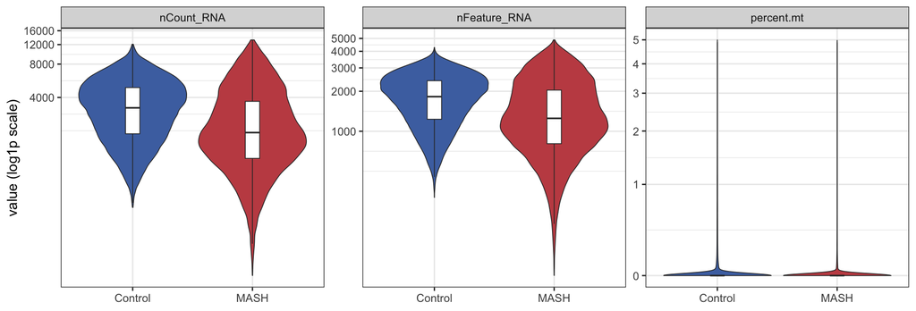

```r
qc <- tidyr::pivot_longer(
  md[, c("condition", "stage", "nCount_RNA", "nFeature_RNA", "percent.mt")],
  cols = c(nCount_RNA, nFeature_RNA, percent.mt),
  names_to = "metric", values_to = "value")

ggplot(subset(qc, !is.na(condition)), aes(condition, value, fill = condition)) +
  geom_violin(scale = "width", linewidth = 0.3) +
  geom_boxplot(width = 0.12, outlier.shape = NA, linewidth = 0.3, fill = "white") +
  facet_wrap(~ metric, scales = "free_y") +
  scale_y_continuous(trans = "log1p") +
  scale_fill_manual(values = c(Control = "#4C72B0", MASH = "#C44E52")) +
  labs(x = NULL, y = "value (log1p scale)") +
  theme_bw(base_size = 11) + theme(legend.position = "none")
```

For reference, the filters already applied by the source study, from its supplementary methods: singlets were retained on gene and read count with a per-donor threshold (count greater than 0.2 times that donor’s median) and genes expressed in fewer than 0.25% of cells in a donor were removed. At sample level, donors with a median below 200 genes per cell were excluded, along with one principal-component outlier and three samples failing genome-transcriptome concordance. Ambient RNA was removed with Cellbender and doublets with DoubletFinder before any of that. The checks below are therefore validation of an already-filtered object, not a second round of filtering.

`percent.mt` is essentially zero across the dataset (median 0, maximum 5%). That is the expected behavior for single-nucleus data, where mitochondrial transcripts are largely excluded with the cytoplasm. Mitochondrial filtering is not a meaningful QC axis here, and applying a conventional 5-10% threshold wouldn’t really be meaningful.

Depth differs modestly between conditions, which is worth knowing but is handled downstream: pseudobulk DE models library size explicitly through DESeq2’s size factors, and proportions are depth-invariant by construction.

### Confounding

The design can only adjust for variables that vary *within* condition. Two checks decide the model formula.

```r
# Does any donor contribute more than one condition?
per_donor <- table(md[[COL_DONOR]], md[[COL_STAGE]])
multi <- sum(rowSums(per_donor > 0) > 1)

meta_cols <- colnames(readRDS(cache_path("meta.rds")))

data.frame(
  Check = c("Metadata columns deposited",
            "Donors contributing >1 disease stage",
            "Batch / chemistry / center variable present"),
  Result = c(paste(meta_cols, collapse = ", "),
             as.character(multi),
             "none")
) |> kable(caption = "Design checks determining the DE formula.")
```

Design checks determining the DE formula.

| Check | Result |
| --- | --- |
| Metadata columns deposited | DonorID, nCount_RNA, nFeature_RNA, percent.mt, Cell_type_broad, Cell_type_detailed, Disease_group |
| Donors contributing >1 disease stage | 0 |
| Batch / chemistry / center variable present | none |

Every donor contributes exactly one disease stage, so **donor is nested within condition**. It therefore cannot enter the design: a donor term would absorb the between-donor variation that *is* the condition effect. This is a correctness constraint rather than a modeling preference.

The deposited metadata carries no batch, chemistry, sequencing-run or center variable. There is consequently nothing to adjust for, and the design stays `~ condition`. This is a single-center Korean cohort, so the risk of hidden batch-condition confounding is lower than in a multi-dataset atlas.

## Verifying annotations

Every claim below rests on the deposited labels, so they are checked against canonical liver markers before use. Expression is summarized per cell type from the on-disk counts: library-size normalized to 10,000, `log1p` transformed.

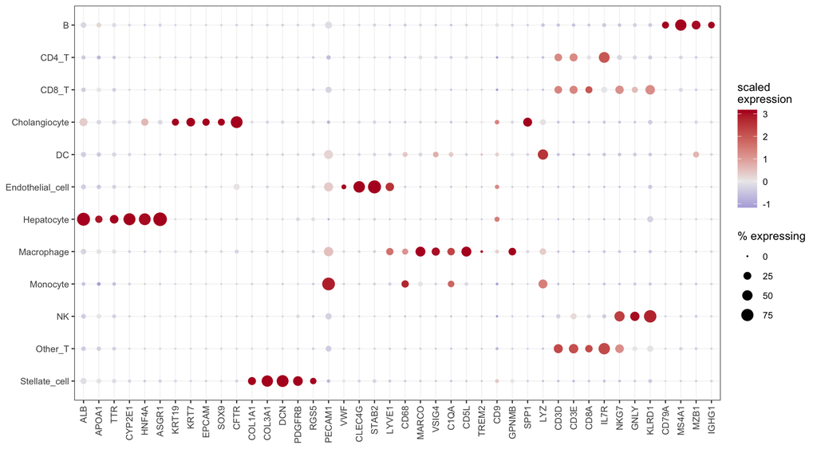

```r
mk <- cached("markers_broad.rds", {
  library(BPCells)
  mat  <- open_matrix_dir("bpcells_counts")
  meta <- readRDS(cache_path("meta.rds"))
  keep <- !meta[[COL_CT_BROAD]] %in% DROP_LABELS
  ct   <- factor(as.character(meta[[COL_CT_BROAD]])[keep])
  sub  <- mat[, which(keep)]
  normed <- log1p(multiply_cols(sub, 1e4 / colSums(sub)))
  genes  <- intersect(unique(unlist(LIVER_MARKERS)), rownames(mat))
  avg <- pseudobulk_matrix(normed[genes, ], cell_groups = ct, method = "mean")
  nz  <- pseudobulk_matrix(sub[genes, ],    cell_groups = ct, method = "nonzeros")
  pct <- sweep(nz, 2, as.integer(table(ct)), "/") * 100
  flat <- utils::stack(LIVER_MARKERS)
  data.frame(gene = rep(rownames(avg), ncol(avg)),
             cell_type = rep(colnames(avg), each = nrow(avg)),
             avg_exp = as.vector(avg), pct_exp = as.vector(pct),
             panel = as.character(flat$ind[match(rep(rownames(avg), ncol(avg)),
                                                 flat$values)]))
})

# Scale each gene across cell types so the dotplot shows specificity, not
# absolute abundance: a gene high everywhere is not evidence for any label.
mk <- mk |>
  group_by(gene) |>
  mutate(z = as.numeric(scale(avg_exp))) |>
  ungroup()
mk$gene      <- factor(mk$gene, levels = intersect(unlist(LIVER_MARKERS), mk$gene))
mk$cell_type <- factor(mk$cell_type, levels = rev(sort(unique(mk$cell_type))))

ggplot(mk, aes(gene, cell_type)) +
  geom_point(aes(size = pct_exp, colour = z)) +
  scale_colour_gradient2(low = "#3B4CC0", mid = "grey92", high = "#B40426",
                         midpoint = 0, name = "scaled\nexpression") +
  scale_size_continuous(range = c(0.2, 5), name = "% expressing") +
  labs(x = NULL, y = NULL) +
  theme_bw(base_size = 10) +
  theme(axis.text.x = element_text(angle = 90, hjust = 1, vjust = 0.5),
        panel.grid.major = element_line(linewidth = 0.2))
```

Each label expresses its canonical markers: hepatocytes *ALB*, *ASGR1*, *CYP2E1*, *HNF4A*; endothelial cells the sinusoidal program *STAB2*, *CLEC4G*, *LYVE1*; stellate cells *DCN*, *COL3A1*, *PDGFRB*; macrophages the Kupffer set *MARCO*, *VSIG4*, *CD5L*; and the lymphoid labels their respective *CD3*, *KLRD1*/*GNLY* and *MS4A1*/*CD79A* markers.

Two labels warrant an explicit note. Monocytes score highest for *PECAM1*, which initially looks like endothelial contamination. It is not: *PECAM1* is CD31, genuinely expressed on monocytes, and the population carries monocyte-restricted *FCN1* and *CSF1R* while lacking the endothelial-restricted *VWF* and *EGFL7*. Dendritic cells likewise carry *FLT3*, *IRF8* and *CD1C*. Both labels are sound. They are nonetheless the two smallest populations (427 and 925 nuclei), which limits them later on power grounds rather than on annotation quality.

`Other_T` and `Stellate_cell_misc` are heterogeneous residual labels. They are retained so that proportions sum over the whole tissue, but no biological conclusion is drawn from their expression results.

### The detailed labels

The deposit also ships a finer annotation, which subdivides only two lineages: hepatocytes by zonation and stellate cells by state. The same marker panel is applied to it.

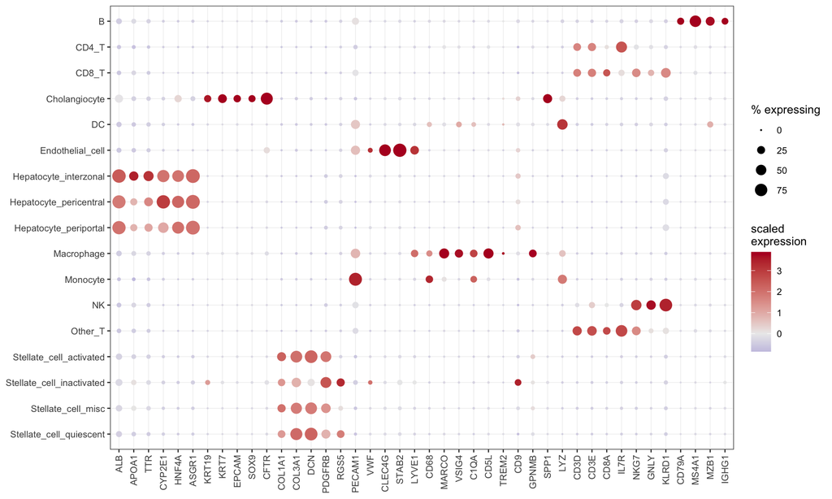

```r
mk_fine <- cached("markers_detailed.rds", {
  library(BPCells)
  mat  <- open_matrix_dir("bpcells_counts")
  meta <- readRDS(cache_path("meta.rds"))
  keep <- !meta[[COL_CT_FINE]] %in% DROP_LABELS
  ctf  <- factor(as.character(meta[[COL_CT_FINE]])[keep])
  sub  <- mat[, which(keep)]
  normed <- log1p(multiply_cols(sub, 1e4 / colSums(sub)))
  genes  <- intersect(unique(unlist(LIVER_MARKERS)), rownames(mat))
  avg <- pseudobulk_matrix(normed[genes, ], cell_groups = ctf, method = "mean")
  nz  <- pseudobulk_matrix(sub[genes, ],    cell_groups = ctf, method = "nonzeros")
  pct <- sweep(nz, 2, as.integer(table(ctf)), "/") * 100
  data.frame(gene = rep(rownames(avg), ncol(avg)),
             cell_type = rep(colnames(avg), each = nrow(avg)),
             avg_exp = as.vector(avg), pct_exp = as.vector(pct))
})

mk_fine <- mk_fine |> group_by(gene) |>
  mutate(z = as.numeric(scale(avg_exp))) |> ungroup()
mk_fine$gene <- factor(mk_fine$gene, levels = intersect(unlist(LIVER_MARKERS), mk_fine$gene))
mk_fine$cell_type <- factor(mk_fine$cell_type, levels = rev(sort(unique(mk_fine$cell_type))))

ggplot(mk_fine, aes(gene, cell_type)) +
  geom_point(aes(size = pct_exp, colour = z)) +
  scale_colour_gradient2(low = "#3B4CC0", mid = "grey92", high = "#B40426",
                         midpoint = 0, name = "scaled\nexpression") +
  scale_size_continuous(range = c(0.2, 5), name = "% expressing") +
  labs(x = NULL, y = NULL) +
  theme_bw(base_size = 10) +
  theme(axis.text.x = element_text(angle = 90, hjust = 1, vjust = 0.5),
        panel.grid.major = element_line(linewidth = 0.2))
```

The three hepatocyte zones share the hepatocyte marker profile, as they should: zonation is a gradient within a lineage, not a change of identity. The stellate substates mostly share the stellate profile.

One does not, and it matters for how the stellate results are read.

```r
sub_expr <- cached("stellate_subtype_expr.rds", {
  library(BPCells)
  mat  <- open_matrix_dir("bpcells_counts")
  meta <- readRDS(cache_path("meta.rds"))
  sel  <- grepl("^Stellate", meta[[COL_CT_FINE]])
  ctf  <- factor(as.character(meta[[COL_CT_FINE]])[sel])
  sb   <- mat[, which(sel)]
  nm   <- log1p(multiply_cols(sb, 1e4 / colSums(sb)))
  g <- c("DCN", "RBP1", "LRAT", "CYGB", "HGF", "COL1A1", "COL1A2",
         "PDGFRB", "TAGLN", "ACTA2", "PPARG",
         "MYH11", "MYLK", "MYL9", "NOTCH3", "RGS5")
  g <- g[g %in% rownames(mat)]
  t(pseudobulk_matrix(nm[g, ], cell_groups = ctf, method = "mean"))
})
rownames(sub_expr) <- sub("Stellate_cell_", "", rownames(sub_expr))

kable(round(sub_expr[, c("LRAT", "DCN", "RBP1", "ACTA2", "TAGLN",
                         "MYH11", "NOTCH3", "RGS5")], 2),
      caption = "Stellate subclusters. Left: hepatic stellate identity. Right: smooth-muscle and pericyte genes.")
```

Stellate subclusters. Left: hepatic stellate identity. Right: smooth-muscle and pericyte genes.

|  | LRAT | DCN | RBP1 | ACTA2 | TAGLN | MYH11 | NOTCH3 | RGS5 |
| --- | --- | --- | --- | --- | --- | --- | --- | --- |
| activated | 0.09 | 2.04 | 0.26 | 0.45 | 0.21 | 0.04 | 0.04 | 0.02 |
| inactivated | 0.04 | 0.41 | 0.16 | 1.34 | 0.72 | 1.25 | 0.70 | 0.69 |
| misc | 0.13 | 1.72 | 0.37 | 0.37 | 0.20 | 0.09 | 0.04 | 0.11 |
| quiescent | 0.43 | 2.04 | 0.91 | 0.35 | 0.11 | 0.04 | 0.00 | 0.41 |

The subcluster labeled `Stellate_cell_inactivated` carries 14-fold more *MYH11* than any other stellate subcluster, plus the only appreciable *NOTCH3*, while holding the **lowest** *LRAT* and *DCN* of the four. *MYH11* is smooth-muscle myosin heavy chain and is not expressed by hepatic stellate cells in any activation state, and a genuinely inactivated stellate cell that has reverted after activation retains its lipid-storing identity markers. This population has neither.

It is therefore better described as vascular smooth muscle or pericyte than as a stellate cell of any state, and it is treated that way in the detailed differential expression below, **where it is relabeled `Mural_VSMC`**. The consequences of the mislabel for the aggregate stellate results are worked through in the supplementary material.

### Testing for myofibroblasts

**No myofibroblast population is recovered, which bounds every fibrosis claim.** *TREM2* is effectively undetected here despite being present in the object, and the fibrillar collagens do not move significantly in stellate cells. It would be easy to attribute both to single-nucleus chemistry. For *TREM2* that is reasonable. For the collagens it is not, and the distinction matters enough to test rather than assume.

```r
detect <- cached("snrna_detection.rds", {
  library(BPCells)
  mt   <- open_matrix_dir("bpcells_counts")
  meta <- readRDS(cache_path("meta.rds"))
  sel  <- meta[[COL_CT_BROAD]] == "Stellate_cell"
  sb   <- mt[, which(sel)]
  one  <- rep("all", ncol(sb))
  nz   <- as.vector(pseudobulk_matrix(sb, cell_groups = one, method = "nonzeros"))
  su   <- as.vector(pseudobulk_matrix(sb, cell_groups = one, method = "sum"))
  tot  <- colSums(sb)
  list(tab = data.frame(gene = rownames(sb), pct = nz / ncol(sb) * 100,
                        cpm = su / sum(su) * 1e6),
       n_cells = ncol(sb), median_umi = median(tot))
})

col_dist <- col1a1_counts()

d <- detect$tab; d$rank <- rank(-d$cpm)
g <- c("COL3A1", "COL1A2", "COL1A1", "COL4A1", "FN1")
i <- match(g, d$gene)

# Detection expected from sequencing depth alone, if counts were Poisson.
expected <- (1 - exp(-d$cpm[i] * detect$median_umi / 1e6)) * 100

kable(data.frame(
  Gene = g,
  CPM = round(d$cpm[i]),
  `Rank of 24,615` = round(d$rank[i]),
  `% nuclei detected` = round(d$pct[i], 1),
  `% expected from depth` = round(expected, 1),
  check.names = FALSE), row.names = FALSE,
  caption = "Observed detection in stellate nuclei against what sequencing depth alone predicts.")
```

Observed detection in stellate nuclei against what sequencing depth alone predicts.

| Gene | CPM | Rank of 24,615 | % nuclei detected | % expected from depth |
| --- | --- | --- | --- | --- |
| COL3A1 | 658 | 135 | 63.2 | 74.1 |
| COL1A2 | 262 | 629 | 35.4 | 41.6 |
| COL1A1 | 161 | 1258 | 26.5 | 28.1 |
| COL4A1 | 161 | 1252 | 24.4 | 28.2 |
| FN1 | 24 | 7046 | 2.9 | 4.8 |

Observed detection tracks the depth expectation closely for every collagen tested, so there is no evidence of selective loss of this transcript class. *COL3A1* is the 135th most abundant gene in stellate nuclei and is detected in 63.2% of them. Collagen transcripts are clearly capturable in this preparation.

**The problem is that the cells that should express *COL1A1* highly are not present!**

```r
kable(data.frame(
  `COL1A1 counts per nucleus` = c("0", "1-2", "3-4", "5-9", "10 or more"),
  `Nuclei` = c(sum(col_dist == 0), sum(col_dist %in% 1:2), sum(col_dist %in% 3:4),
               sum(col_dist %in% 5:9), sum(col_dist >= 10)),
  check.names = FALSE), row.names = FALSE,
  caption = "COL1A1 across all nuclei in the dataset.")
```

COL1A1 across all nuclei in the dataset.

| COL1A1 counts per nucleus | Nuclei |
| --- | --- |
| 0 | 246390 |
| 1-2 | 2624 |
| 3-4 | 177 |
| 5-9 | 36 |
| 10 or more | 6 |

The highest *COL1A1* count in any nucleus in the entire dataset is 25, and only 6 nuclei carry ten or more. In a collagen-producing myofibroblast, *COL1A1* is among the most abundant transcripts in the library by a wide margin. A dataset-wide maximum of 25 counts is not a detection failure, it is the absence of the cell type.

Two things most plausibly explain that absence, and neither is assay chemistry. Myofibroblasts in fibrotic tissue are embedded in dense cross-linked matrix and are recovered poorly by dissociation, a bias that is worse the less tissue there is to work with and these are from needle core biopsy samples. And the cohort tops out at F3-F4 fibrosis in ten donors, which is not end-stage disease. Consistent with both, the stellate compartment is only 4.3% of the nuclei analyzed, and stellate nuclei are among the most shallowly sequenced in the dataset at a median of 2,054 UMIs.

The consequence for reading this report is specific. Abundance and pathway-level results do not depend on recovering myofibroblasts. Statements about stellate cells describe the hepatic stellate populations that were recovered, which are largely quiescent and activated states rather than matrix-producing myofibroblasts. Nothing here should be taken as evidence about myofibroblast biology in MASH, in either direction, and the flat collagen result in particular is not evidence against fibrogenesis. A dataset built on larger tissue pieces, precision-cut slices (as I’ve done in the past) or resections rather than cores, would be the appropriate design for that question.

# Axis 1: which cell types change in abundance

## Composition across the disease spectrum

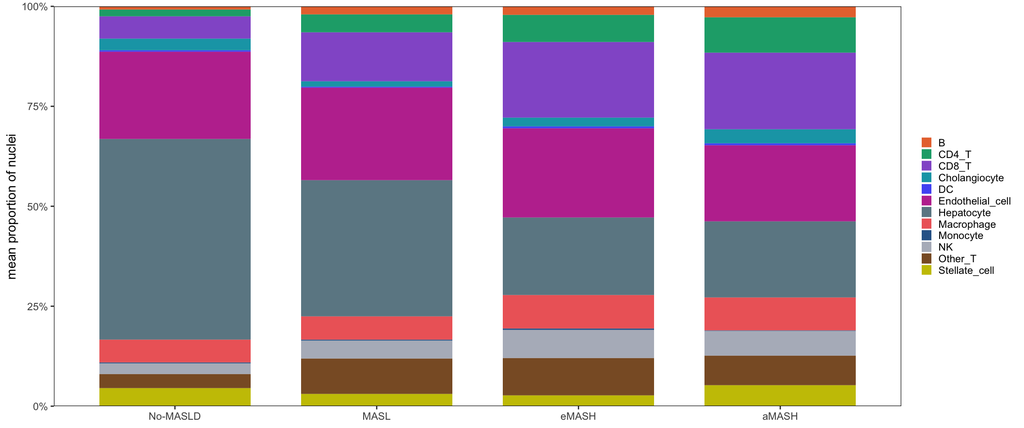

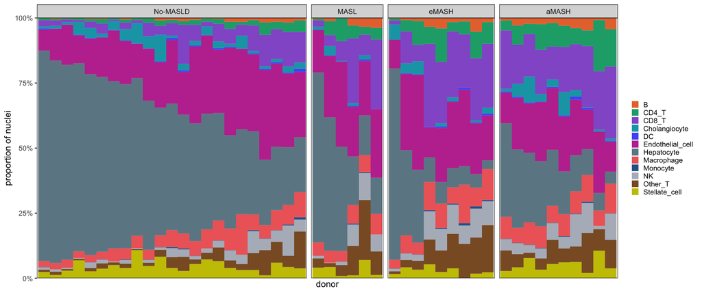

```r
props <- cached("donor_props.rds", {
  tab <- table(md[[COL_DONOR]], md[[COL_CT_BROAD]])
  list(counts = tab, props = sweep(tab, 1, rowSums(tab), "/"))
})$props

dstage <- donors$stage[match(rownames(props), donors$donor)]

long <- data.frame(
  donor = rep(rownames(props), ncol(props)),
  cell_type = rep(colnames(props), each = nrow(props)),
  prop = as.vector(props),
  stage = rep(dstage, ncol(props)))

# Order donors within stage by hepatocyte fraction, so the gradient is visible.
hep <- props[, "Hepatocyte"]
long$donor <- factor(long$donor, levels = rownames(props)[order(dstage, -hep)])

pal <- setNames(
  c("#E8743B", "#19A979", "#945ECF", "#13A4B4", "#525DF4", "#BF399E",
    "#6C8893", "#EE6868", "#2F6497", "#B4B9C4", "#8A5B2E", "#C9C300"),
  sort(unique(long$cell_type)))

# Aggregated view: mean of the per-donor proportions within each stage, so every
# donor contributes equally regardless of how many nuclei it yielded.
agg <- aggregate(prop ~ cell_type + stage, long, mean)

p0 <- ggplot(agg, aes(stage, prop, fill = cell_type)) +
  geom_col(width = 0.75) +
  scale_fill_manual(values = pal, name = NULL) +
  scale_y_continuous(expand = c(0, 0), labels = scales::percent) +
  labs(x = NULL, y = "mean proportion of nuclei") +
  theme_bw(base_size = 10) +
  theme(panel.grid = element_blank(), legend.key.size = unit(9, "pt"))
p0
p1 <- ggplot(long, aes(donor, prop, fill = cell_type)) +
  geom_col(width = 1) +
  facet_grid(~ stage, scales = "free_x", space = "free_x") +
  scale_fill_manual(values = pal, name = NULL) +
  scale_y_continuous(expand = c(0, 0), labels = scales::percent) +
  labs(x = "donor", y = "proportion of nuclei") +
  theme_bw(base_size = 10) +
  theme(axis.text.x = element_blank(), axis.ticks.x = element_blank(),
        panel.grid = element_blank(), legend.key.size = unit(9, "pt"))
p1
```

The first panel aggregates within stage (and mirrors Figure 1b of Hong et al.), averaging the per-donor proportions so that each donor counts once regardless of how many nuclei it contributed. The second shows every donor separately. The hepatocyte compartment visibly contracts across the progression while lymphoid and myeloid compartments fill the space, and the effect is consistent enough to be apparent donor by donor rather than only on group means.

```r
stage_mean <- sapply(levels(donors$stage), function(s)
  colMeans(props[dstage == s, , drop = FALSE]) * 100)
stage_mean <- stage_mean[order(-stage_mean[, "No-MASLD"]), ]
kable(round(stage_mean, 2),
      caption = "Mean per-donor cell-type proportion (%) by disease stage.")
```

Mean per-donor cell-type proportion (%) by disease stage.

|  | No-MASLD | MASL | eMASH | aMASH |
| --- | --- | --- | --- | --- |
| Hepatocyte | 50.20 | 34.06 | 19.45 | 19.07 |
| Endothelial_cell | 21.79 | 23.17 | 22.31 | 18.99 |
| Macrophage | 5.71 | 5.86 | 8.34 | 8.21 |
| CD8_T | 5.60 | 12.30 | 18.88 | 19.23 |
| Stellate_cell | 4.49 | 3.07 | 2.72 | 5.19 |
| Other_T | 3.53 | 8.79 | 9.31 | 7.47 |
| Cholangiocyte | 2.95 | 1.30 | 2.23 | 3.44 |
| NK | 2.71 | 4.57 | 7.04 | 6.13 |
| CD4_T | 1.72 | 4.50 | 6.72 | 8.85 |
| B | 0.76 | 2.01 | 2.21 | 2.73 |
| DC | 0.37 | 0.21 | 0.43 | 0.50 |
| Monocyte | 0.15 | 0.16 | 0.38 | 0.18 |

Hepatocytes fall from 50.2% of nuclei in controls to 19.1% in advanced MASH. The source paper reports approximately 48% to 21% for the same comparison, so this recovers their headline compositional result independently.

## Differential abundance testing

`propeller` operates on per-donor proportions: logit-transformed, then moderated t-tests with empirical Bayes shrinkage across cell types. The donor is the unit throughout, so 48 donors give 48 observations, not 249,233.

```r
library(speckle)
sub_md <- md[!is.na(md$condition), ]

prop_res <- cached("propeller_primary.rds", propeller(
  clusters = sub_md[[COL_CT_BROAD]],
  sample   = sub_md[[COL_DONOR]],
  group    = sub_md$condition))

prop_tab <- data.frame(
  `Cell type`  = as.character(prop_res$BaselineProp.clusters),
  `Control %`  = round(prop_res$PropMean.Control * 100, 2),
  `MASH %`     = round(prop_res$PropMean.MASH * 100, 2),
  `Fold change`= round(prop_res$PropMean.MASH / prop_res$PropMean.Control, 2),
  FDR          = signif(prop_res$FDR, 3),
  check.names  = FALSE)
prop_tab <- prop_tab[order(-prop_tab$`Fold change`), ]

# Significant cell types are marked in the table rather than left to the reader
# to derive from the FDR column.
prop_show <- prop_tab
sig_ct <- prop_show$FDR < FDR_CUTOFF
prop_show$`Cell type` <- ifelse(sig_ct, paste0("**", prop_show$`Cell type`, "**"),
                                prop_show$`Cell type`)
kable(prop_show, row.names = FALSE,
      caption = paste0("propeller, Control (n=23) vs MASH (n=19), ranked by fold change. ",
                       "Fold change is MASH relative to Control. Cell types in bold are ",
                       "significant at Benjamini-Hochberg FDR < ", FDR_CUTOFF, " (",
                       sum(sig_ct), " of ", nrow(prop_show), ")."))
```

propeller, Control (n=23) vs MASH (n=19), ranked by fold change. Fold change is MASH relative to Control. Cell types in bold are significant at Benjamini-Hochberg FDR < 0.05 (8 of 12).

| Cell type | Control % | MASH % | Fold change | FDR |
| --- | --- | --- | --- | --- |
| **CD4_T** | 1.72 | 7.84 | 4.56 | 1.00e-07 |
| **CD8_T** | 5.60 | 19.06 | 3.40 | 1.40e-06 |
| **B** | 0.76 | 2.48 | 3.26 | 6.70e-06 |
| **NK** | 2.71 | 6.57 | 2.42 | 3.60e-04 |
| **Other_T** | 3.53 | 8.34 | 2.36 | 3.60e-04 |
| **Monocyte** | 0.15 | 0.27 | 1.80 | 1.09e-02 |
| **Macrophage** | 5.71 | 8.27 | 1.45 | 1.11e-02 |
| DC | 0.37 | 0.47 | 1.25 | 2.56e-01 |
| Cholangiocyte | 2.95 | 2.87 | 0.97 | 2.89e-01 |
| Endothelial_cell | 21.79 | 20.56 | 0.94 | 7.42e-01 |
| Stellate_cell | 4.49 | 4.02 | 0.90 | 3.58e-01 |
| **Hepatocyte** | 50.20 | 19.25 | 0.38 | 1.30e-06 |

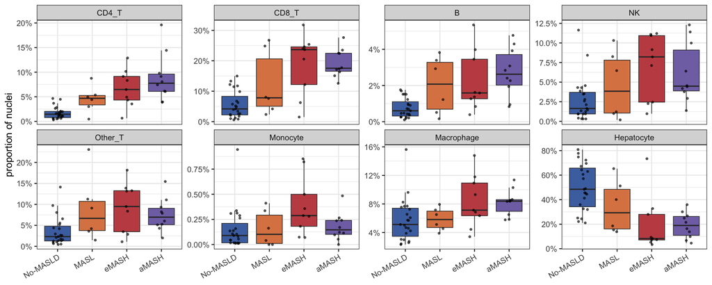

```r
# Every cell type significant in the primary contrast, ordered by fold change,
# so the panel and the table agree.
show <- prop_tab$`Cell type`[prop_tab$FDR < FDR_CUTOFF]
pl <- subset(long, cell_type %in% show & !is.na(stage))
pl$cell_type <- factor(pl$cell_type, levels = show)

ggplot(pl, aes(stage, prop, fill = stage)) +
  geom_boxplot(outlier.shape = NA, linewidth = 0.3) +
  geom_jitter(width = 0.15, size = 0.7, alpha = 0.6) +
  facet_wrap(~ cell_type, scales = "free_y", nrow = 2) +
  scale_y_continuous(labels = scales::percent) +
  scale_fill_manual(values = c("#4C72B0", "#DD8452", "#C44E52", "#8172B3")) +
  labs(x = NULL, y = "proportion of nuclei") +
  theme_bw(base_size = 10) +
  theme(legend.position = "none",
        axis.text.x = element_text(angle = 30, hjust = 1))
```

8 of 12 cell types change significantly in abundance. The pattern is a single coherent event: hepatocytes are lost (0.38-fold, FDR 1.3e-06) and every significant immune population expands, led by CD4 T cells (4.6-fold) and CD8 T cells (3.4-fold).

Because proportions are compositional, these are not independent measurements. A large loss of hepatocytes mechanically raises every other fraction. The immune expansion should therefore be read as relative enrichment, not as proof of absolute immune infiltration, and that caveat applies to any proportion-based analysis of this kind.

### Abundance across individual disease stages

The two-group contrast pools early and advanced MASH. Testing the stages against each other separately shows where along the progression each shift occurs.

```r
stagewise <- cached("propeller_stagewise.rds", {
  out <- list()
  for (cc in STAGE_CONTRASTS) {
    sel <- md[[COL_STAGE]] %in% cc
    out[[paste(cc, collapse = " vs ")]] <- propeller(
      clusters = md[[COL_CT_BROAD]][sel],
      sample   = md[[COL_DONOR]][sel],
      group    = factor(as.character(md[[COL_STAGE]])[sel], levels = cc))
  }
  out
})

stage_table <- function(key) {
  r <- stagewise[[key]]
  cts <- as.character(r$BaselineProp.clusters)
  # propeller reports the ratio of the first group to the second; invert so the
  # column reads as change in the later stage relative to the earlier one.
  fc <- round(1 / r$PropRatio, 2)
  d <- data.frame(`Cell type` = ifelse(r$FDR < FDR_CUTOFF, paste0("**", cts, "**"), cts),
                  `Fold change` = fc, FDR = signif(r$FDR, 3), check.names = FALSE)
  d <- d[order(-d$`Fold change`), ]
  kable(d, row.names = FALSE,
        caption = paste0(key, ". Fold change is the later stage relative to the earlier. ",
                         "Bold: FDR < ", FDR_CUTOFF, " (", sum(r$FDR < FDR_CUTOFF),
                         " of ", nrow(r), ")."))
}
```

```r
stage_table("control vs eMASH")
```

control vs eMASH. Fold change is the later stage relative to the earlier. Bold: FDR < 0.05 (8 of 12).

| Cell type | Fold change | FDR |
| --- | --- | --- |
| **CD4_T** | 3.91 | 0.000300 |
| **CD8_T** | 3.37 | 0.001800 |
| **B** | 2.90 | 0.004060 |
| **Other_T** | 2.63 | 0.006140 |
| **NK** | 2.60 | 0.006140 |
| **Monocyte** | 2.49 | 0.006140 |
| Macrophage | 1.46 | 0.097200 |
| DC | 1.14 | 0.564000 |
| Endothelial_cell | 1.02 | 0.897000 |
| Cholangiocyte | 0.76 | 0.097200 |
| **Stellate_cell** | 0.61 | 0.043600 |
| **Hepatocyte** | 0.39 | 0.000198 |

```r
stage_table("control vs aMASH")
```

control vs aMASH. Fold change is the later stage relative to the earlier. Bold: FDR < 0.05 (7 of 12).

| Cell type | Fold change | FDR |
| --- | --- | --- |
| **CD4_T** | 5.15 | 3.00e-07 |
| **B** | 3.59 | 2.73e-05 |
| **CD8_T** | 3.43 | 1.25e-05 |
| **NK** | 2.26 | 5.02e-03 |
| **Other_T** | 2.11 | 4.79e-03 |
| **Macrophage** | 1.44 | 3.39e-02 |
| DC | 1.35 | 2.24e-01 |
| Monocyte | 1.17 | 2.31e-01 |
| Cholangiocyte | 1.17 | 7.73e-01 |
| Stellate_cell | 1.16 | 5.33e-01 |
| Endothelial_cell | 0.87 | 5.61e-01 |
| **Hepatocyte** | 0.38 | 1.68e-05 |

```r
stage_table("eMASH vs aMASH")
```

eMASH vs aMASH. Fold change is the later stage relative to the earlier. Bold: FDR < 0.05 (0 of 12).

| Cell type | Fold change | FDR |
| --- | --- | --- |
| Stellate_cell | 1.91 | 0.307 |
| Cholangiocyte | 1.54 | 0.762 |
| CD4_T | 1.32 | 0.762 |
| B | 1.24 | 0.762 |
| DC | 1.18 | 0.831 |
| CD8_T | 1.02 | 0.831 |
| Hepatocyte | 0.98 | 0.831 |
| Macrophage | 0.98 | 0.845 |
| NK | 0.87 | 0.845 |
| Endothelial_cell | 0.85 | 0.831 |
| Other_T | 0.80 | 0.845 |
| Monocyte | 0.47 | 0.307 |

Control against early MASH and control against advanced MASH both recover the hepatocyte loss and lymphoid expansion seen in the pooled contrast. The early-versus-advanced comparison is informative but nothing is signficant after FDR adjustment.

## Stage-resolved abundance: where the two-group test misleads

Stellate cells are the central fibrosis cell type, yet they are flat in the two-group contrast (FDR 0.36). Splitting MASH back into its two stages explains why.

```r
nonmono <- stage_mean[c("Stellate_cell", "Cholangiocyte"), ]
kable(round(nonmono, 2),
      caption = "Two cell types whose abundance is not monotonic across the progression (%).")
```

Two cell types whose abundance is not monotonic across the progression (%).

|  | No-MASLD | MASL | eMASH | aMASH |
| --- | --- | --- | --- | --- |
| Stellate_cell | 4.49 | 3.07 | 2.72 | 5.19 |
| Cholangiocyte | 2.95 | 1.30 | 2.23 | 3.44 |

Both dip through early disease and then expand at advanced fibrosis. Averaging eMASH and aMASH into a single MASH arm cancels the change, which is exactly why the two-group test returns nothing for stellate cells.

```r
ea <- stagewise[["eMASH vs aMASH"]]
kable(data.frame(
  `Cell type` = as.character(ea$BaselineProp.clusters),
  `Fold change (aMASH/eMASH)` = round(1 / ea$PropRatio, 2),
  `P` = signif(ea$P.Value, 3),
  FDR = signif(ea$FDR, 3),
  check.names = FALSE)[1:5, ], row.names = FALSE,
  caption = "Top five cell types, early vs advanced MASH (9 vs 10 donors).")
```

Top five cell types, early vs advanced MASH (9 vs 10 donors).

| Cell type | Fold change (aMASH/eMASH) | P | FDR |
| --- | --- | --- | --- |
| Stellate_cell | 1.91 | 0.0321 | 0.307 |
| Monocyte | 0.47 | 0.0512 | 0.307 |
| CD4_T | 1.32 | 0.2390 | 0.762 |
| Cholangiocyte | 1.54 | 0.3020 | 0.762 |
| B | 1.24 | 0.3170 | 0.762 |

Stellate cells are the strongest signal in this contrast, expanding 1.9-fold from early to advanced MASH (p 0.032).

Again, this does not survive multiple-testing correction (FDR 0.31), and the comparison rests on 9 versus 10 donors. I think what’s going on here is a suggestive stage-specific pattern that is consistent with fibrosis biology and with the significant expression changes reported below, though not an established differential abundance result. It is reported because a two-group-only analysis would have recorded stellate cells as unchanged which isn’t entirely true.

# Axis 2: how each cell type is transcriptionally perturbed

## Building donor-level pseudobulk

Counts are summed within each (cell type, donor) pair. This is the step that makes the donor the replication unit: one pseudo-sample per donor per cell type, carrying that donor’s condition label exactly once.

```r
MIN_CELLS  <- 20   # a pseudo-sample must aggregate at least this many nuclei
MIN_DONORS <- 10   # a cell type needs this many donors in each group to be tested

pb <- cached("pseudobulk_broad.rds", {
  library(BPCells)
  mat  <- open_matrix_dir("bpcells_counts")
  meta <- readRDS(cache_path("meta.rds"))
  keep <- !meta[[COL_CT_BROAD]] %in% DROP_LABELS
  grp  <- paste(as.character(meta[[COL_CT_BROAD]])[keep],
                as.character(meta[[COL_DONOR]])[keep], sep = "__")
  pseudobulk_matrix(mat[, which(keep)], cell_groups = grp, method = "sum")
})

pbmeta <- cached("pseudobulk_meta_broad.rds", {
  key <- do.call(rbind, strsplit(colnames(pb), "__", fixed = TRUE))
  m <- data.frame(pseudosample = colnames(pb), cell_type = key[, 1],
                  donor = key[, 2], stringsAsFactors = FALSE)
  m$n_cells <- as.integer(table(paste(md[[COL_CT_BROAD]], md[[COL_DONOR]],
                                      sep = "__"))[m$pseudosample])
  m$stage     <- donors$stage[match(m$donor, donors$donor)]
  m$condition <- donors$condition[match(m$donor, donors$donor)]
  m
})
pbmeta <- pbmeta[match(colnames(pb), pbmeta$pseudosample), ]

cov <- with(subset(pbmeta, n_cells >= MIN_CELLS & !is.na(condition)),
            table(cell_type, condition))
kable(cov, caption = paste0("Donors passing the ", MIN_CELLS,
      "-nucleus threshold, per cell type. Cell types below ", MIN_DONORS,
      " donors in either group are not tested."))
```

Donors passing the 20-nucleus threshold, per cell type. Cell types below 10 donors in either group are not tested.

|  | Control | MASH |
| --- | --- | --- |
| B | 17 | 14 |
| CD4_T | 23 | 18 |
| CD8_T | 23 | 19 |
| Cholangiocyte | 23 | 13 |
| DC | 11 | 9 |
| Endothelial_cell | 23 | 19 |
| Hepatocyte | 23 | 19 |
| Macrophage | 23 | 19 |
| Monocyte | 4 | 4 |
| NK | 23 | 19 |
| Other_T | 23 | 19 |
| Stellate_cell | 23 | 18 |

Monocytes and dendritic cells fall out here. They are genuine populations, as the marker check established, but at a median of 5 and 16 nuclei per donor their pseudobulk profiles are dominated by sampling noise. They remain in the abundance analysis, where donor proportions are still well estimated.

## Differential expression

DESeq2 per cell type, design `~ condition`.

A gene is called differentially expressed on two criteria together: Benjamini-Hochberg FDR below 0.05, and an absolute log2 fold change of at least 0.25. Significance alone is a statement about confidence, not about size, and with 23 and 19 donors it admits changes too small to be interesting. The effect-size floor is applied as a filter on the results rather than as a null hypothesis in the model, so the reported p-values remain tests against no change. Enrichment analyses later in the report are unaffected as they rank all genes by the test statistic and never threshold.

Donor is deliberately absent from the design. Each donor contributes exactly one condition, so donor is nested within condition; including it would absorb the between-donor variance that constitutes the effect being tested. There is no batch variable in the deposit, so nothing else is available to adjust for.

This differs from the source paper, which ran differential expression cell-level with Seurat `FindMarkers`. That approach treats each nucleus as an independent replicate. With thousands of nuclei per donor the effective sample size is inflated by orders of magnitude, p-values shrink accordingly, and the resulting gene lists reflect the number of cells sequenced as much as the biology. Aggregating to the donor first is the standard correction.

```r
de <- cached("de_primary.rds", {
  library(DESeq2)
  out <- list()
  for (ct in sort(unique(pbmeta$cell_type))) {
    sel <- pbmeta$cell_type == ct & pbmeta$n_cells >= MIN_CELLS &
           !is.na(pbmeta$condition)
    m <- pbmeta[sel, ]
    if (any(table(m$condition) < MIN_DONORS)) next
    cts <- round(pb[, m$pseudosample, drop = FALSE]); mode(cts) <- "integer"
    cts <- cts[rowSums(cts > 0) >= ceiling(ncol(cts) / 3), , drop = FALSE]
    dds <- DESeq(DESeqDataSetFromMatrix(cts, m, ~ condition), quiet = TRUE)
    r <- as.data.frame(results(dds, contrast = c("condition", "MASH", "Control")))
    r$gene <- rownames(r); r$cell_type <- ct
    out[[ct]] <- r[order(r$padj), ]
  }
  out
})

de_severe <- cached("de_aMASH.rds", {
  library(DESeq2)
  out <- list()
  for (ct in sort(unique(pbmeta$cell_type))) {
    sel <- pbmeta$cell_type == ct & pbmeta$n_cells >= MIN_CELLS &
           pbmeta$stage %in% c("No-MASLD", "aMASH")
    m <- pbmeta[sel, ]
    m$grp <- factor(as.character(m$stage), levels = c("No-MASLD", "aMASH"))
    if (any(table(m$grp) < MIN_DONORS)) next
    cts <- round(pb[, m$pseudosample, drop = FALSE]); mode(cts) <- "integer"
    cts <- cts[rowSums(cts > 0) >= ceiling(ncol(cts) / 3), , drop = FALSE]
    dds <- DESeq(DESeqDataSetFromMatrix(cts, m, ~ grp), quiet = TRUE)
    r <- as.data.frame(results(dds, contrast = c("grp", "aMASH", "No-MASLD")))
    r$gene <- rownames(r); r$cell_type <- ct
    out[[ct]] <- r[order(r$padj), ]
  }
  out
})

deg <- data.frame(
  `Cell type` = names(de),
  Up   = sapply(de, function(r) sum(is_de(r) & r$log2FoldChange > 0)),
  Down = sapply(de, function(r) sum(is_de(r) & r$log2FoldChange < 0)),
  check.names = FALSE)
deg$Total <- deg$Up + deg$Down
deg$`vs aMASH` <- sapply(deg$`Cell type`, function(ct)
  if (ct %in% names(de_severe))
    sum(is_de(de_severe[[ct]])) else NA_integer_)
deg <- deg[order(-deg$Total), ]
kable(deg, row.names = FALSE,
      caption = paste0("Differentially expressed genes by cell type (", DE_RULE,
                       "). First three columns are MASH vs Control; the last is ",
                       "control vs advanced MASH alone (NA = too few aMASH donors to test)."))
```

Differentially expressed genes by cell type (FDR < 0.05 and |log2FC| >= 0.25). First three columns are MASH vs Control; the last is control vs advanced MASH alone (NA = too few aMASH donors to test).

| Cell type | Up | Down | Total | vs aMASH |
| --- | --- | --- | --- | --- |
| Hepatocyte | 2884 | 2486 | 5370 | 3992 |
| Endothelial_cell | 1160 | 810 | 1970 | 1538 |
| Macrophage | 676 | 632 | 1308 | 668 |
| Stellate_cell | 563 | 575 | 1138 | 795 |
| Other_T | 301 | 211 | 512 | 283 |
| Cholangiocyte | 83 | 157 | 240 | NA |
| CD8_T | 93 | 30 | 123 | 35 |
| NK | 48 | 42 | 90 | 10 |
| CD4_T | 29 | 35 | 64 | 19 |
| B | 3 | 11 | 14 | NA |

Hepatocytes are by a wide margin the most transcriptionally perturbed cell type (5,370 genes at FDR < 0.05 and |log2FC| >= 0.25), consistent with the source paper’s observation that hepatocytes carry the most change with disease severity and that MASLD heritability is enriched in them.

## Differential expression at detailed resolution

The detailed annotation subdivides hepatocytes by zonation and stellate cells by state. The mural population identified above is relabeled here, since calling it an inactivated stellate cell would misattribute anything it contributes.

```r
de_fine <- cached("de_detailed.rds", {
  library(BPCells); library(DESeq2)
  mt <- open_matrix_dir("bpcells_counts")
  meta <- readRDS(cache_path("meta.rds"))
  meta$ct <- as.character(meta[[COL_CT_FINE]])
  meta$ct[meta$ct == "Stellate_cell_inactivated"] <- "Mural_VSMC"
  k <- !meta$ct %in% DROP_LABELS
  grp <- paste(meta$ct[k], meta[[COL_DONOR]][k], sep = "__")
  p <- pseudobulk_matrix(mt[, which(k)], cell_groups = grp, method = "sum")
  nc <- table(grp); key <- do.call(rbind, strsplit(colnames(p), "__", fixed = TRUE))
  dm <- unique(meta[, c(COL_DONOR, COL_STAGE)]); names(dm) <- c("donor", "stage")
  m <- data.frame(pseudosample = colnames(p), cell_type = key[, 1], donor = key[, 2],
                  n_cells = as.integer(nc[colnames(p)]), stringsAsFactors = FALSE)
  m <- merge(m, dm, by = "donor"); m <- m[match(colnames(p), m$pseudosample), ]
  m$condition <- factor(unname(CONDITION_MAP[as.character(m$stage)]), levels = CONDITION_LEVELS)
  out <- list()
  for (ct in sort(unique(m$cell_type))) {
    sel <- m$cell_type == ct & m$n_cells >= MIN_CELLS & !is.na(m$condition)
    mm <- m[sel, ]; if (any(table(mm$condition) < MIN_DONORS)) next
    cts <- round(p[, mm$pseudosample, drop = FALSE]); mode(cts) <- "integer"
    cts <- cts[rowSums(cts > 0) >= ceiling(ncol(cts) / 3), , drop = FALSE]
    rownames(mm) <- mm$pseudosample
    dds <- DESeq(DESeqDataSetFromMatrix(cts, mm, ~ condition), quiet = TRUE)
    r <- as.data.frame(results(dds, contrast = c("condition", "MASH", "Control")))
    r$gene <- rownames(r); out[[ct]] <- r[order(r$padj), ]
  }
  out
})

fine_tab <- data.frame(
  `Cell type` = names(de_fine),
  DEGs = sapply(de_fine, function(r) sum(is_de(r))),
  check.names = FALSE)
kable(fine_tab[order(-fine_tab$DEGs), ], row.names = FALSE,
      caption = paste0("Differentially expressed genes (", DE_RULE,
                       "), MASH vs Control, detailed annotation."))
```

Differentially expressed genes (FDR < 0.05 and |log2FC| >= 0.25), MASH vs Control, detailed annotation.

| Cell type | DEGs |
| --- | --- |
| Hepatocyte_pericentral | 5070 |
| Hepatocyte_periportal | 3707 |
| Hepatocyte_interzonal | 2502 |
| Endothelial_cell | 1970 |
| Macrophage | 1308 |
| Stellate_cell_quiescent | 696 |
| Other_T | 512 |
| Stellate_cell_activated | 447 |
| Cholangiocyte | 240 |
| Stellate_cell_misc | 201 |
| CD8_T | 123 |
| NK | 90 |
| CD4_T | 64 |
| B | 14 |

14 of the 17 detailed labels clear the donor threshold, against 10 of 12 at broad resolution. Monocytes and dendritic cells fail as before. The mural population fails too, for a reason worth noting: it contracts so sharply in disease that too few MASH donors retain enough of it to test. The correction made above therefore costs nothing.

## The two axes are not the same measurement

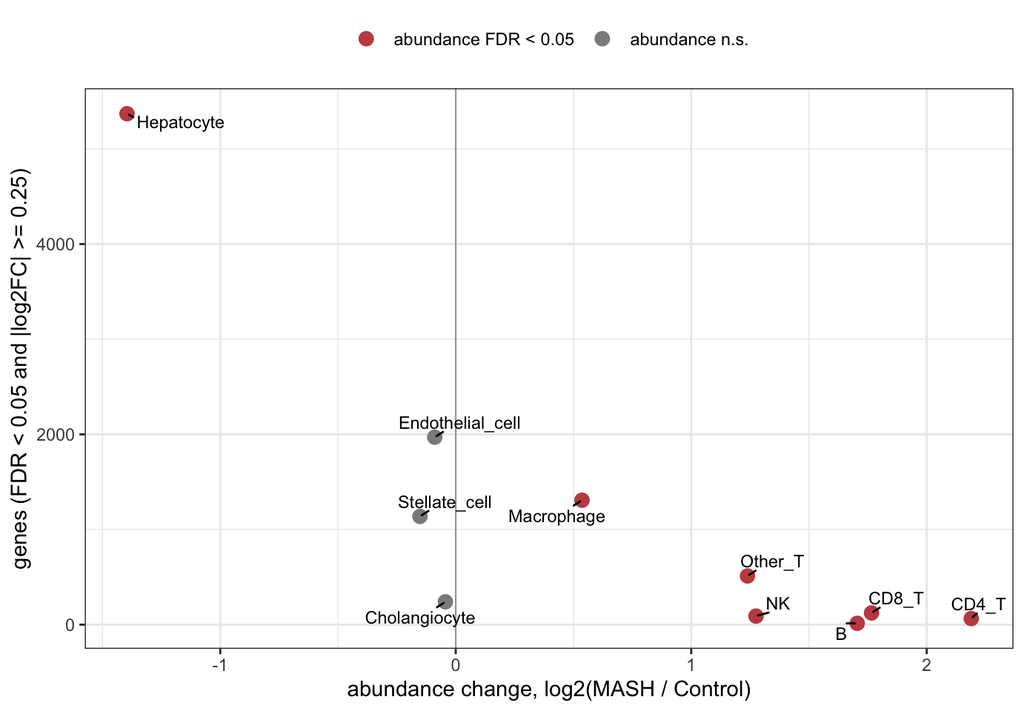

```r
ax <- data.frame(
  cell_type = deg$`Cell type`,
  degs      = deg$Total,
  fc        = prop_tab$`Fold change`[match(deg$`Cell type`, prop_tab$`Cell type`)],
  fdr       = prop_tab$FDR[match(deg$`Cell type`, prop_tab$`Cell type`)])
ax$abund_sig <- ifelse(ax$fdr < 0.05, "abundance FDR < 0.05", "abundance n.s.")

ggplot(ax, aes(log2(fc), degs)) +
  geom_vline(xintercept = 0, linewidth = 0.3, colour = "grey60") +
  geom_point(aes(colour = abund_sig), size = 3) +
  ggrepel::geom_text_repel(aes(label = cell_type), size = 3.1, seed = 1,
                           max.overlaps = 20, min.segment.length = 0) +
  scale_colour_manual(values = c("abundance FDR < 0.05" = "#C44E52",
                                 "abundance n.s." = "grey55"), name = NULL) +
  labs(x = "abundance change, log2(MASH / Control)",
       y = paste0("genes (", DE_RULE, ")")) +
  theme_bw(base_size = 11) + theme(legend.position = "top")
```

The two axes separate cleanly, and the separation is the substantive result.

Endothelial cells are the clearest case. Their abundance does not move at all (fold change 0.94, FDR 0.74), yet they carry 1,970 differentially expressed genes, the second-largest program in the dataset. A composition-only analysis would have called them unperturbed.

The reverse also holds. CD4 and CD8 T cells show the largest abundance changes in the dataset but comparatively modest expression programs (64 and 123 genes). They arrive in greater numbers without substantially altering the program they run.

Hepatocytes are the only cell type strongly perturbed on both axes: they are lost, and those that remain are extensively rewired.

# Synthesis across axes: which cell types are most perturbed, and how

```r
top_genes <- function(ct, up = TRUE, n = 4) {
  if (!ct %in% names(de)) return("not tested")
  r <- de[[ct]]
  r <- r[is_de(r), ]
  r <- r[if (up) order(-r$log2FoldChange) else order(r$log2FoldChange), ]
  if (!nrow(r)) return("-")
  paste(head(r$gene, n), collapse = ", ")
}

syn <- data.frame(
  `Cell type` = prop_tab$`Cell type`,
  `Abundance FC` = prop_tab$`Fold change`,
  `Abundance FDR` = prop_tab$FDR,
  check.names = FALSE)
syn$DEGs <- deg$Total[match(syn$`Cell type`, deg$`Cell type`)]
syn$`Top up`   <- vapply(as.character(syn$`Cell type`), top_genes, "", up = TRUE)
syn$`Top down` <- vapply(as.character(syn$`Cell type`), top_genes, "", up = FALSE)

# Rank on both axes jointly: significant abundance change and size of the
# expression program both count toward "most perturbed".
syn$abund_rank <- rank(-abs(log2(syn$`Abundance FC`)) * (syn$`Abundance FDR` < 0.05))
syn$de_rank    <- rank(-ifelse(is.na(syn$DEGs), 0, syn$DEGs))
syn <- syn[order((syn$abund_rank + syn$de_rank) / 2), ]
syn$`Abundance FDR` <- signif(syn$`Abundance FDR`, 2)
syn$DEGs <- ifelse(is.na(syn$DEGs), "not tested", format(syn$DEGs, big.mark = ","))

kable(syn[, c("Cell type", "Abundance FC", "Abundance FDR", "DEGs",
              "Top up", "Top down")], row.names = FALSE,
      caption = paste0("Cell types ranked by combined perturbation across both axes. ",
                       "Abundance FC is MASH relative to Control; DEGs are genes at ", DE_RULE, "."))
```

Cell types ranked by combined perturbation across both axes. Abundance FC is MASH relative to Control; DEGs are genes at FDR < 0.05 and |log2FC| >= 0.25.

| Cell type | Abundance FC | Abundance FDR | DEGs | Top up | Top down |
| --- | --- | --- | --- | --- | --- |
| Hepatocyte | 0.38 | 1.3e-06 | 5,370 | RPL29, LINC01435, RPL13, RPL7A | AC079061.1, SOCS2, TSPAN5, RP1 |
| CD8_T | 3.40 | 1.4e-06 | 123 | ACADSB, PECR, IL1RAP, ACOX1 | MT-ATP6, UNC5C, GUCY1A1, PCBP3 |
| CD4_T | 4.56 | 1.0e-07 | 64 | PECR, ACADSB, AC104170.1, LEPR | MT-ATP6, CADPS2, STOX2, CST3 |
| Other_T | 2.36 | 3.6e-04 | 512 | ACADSB, IL6ST, LEPR, MAST4 | MT-ATP6, MT-CO3, CD59, LINC02726 |
| Macrophage | 1.45 | 1.1e-02 | 1,308 | LPL, FABP4, TM4SF19, CYP27A1 | HS3ST4, DAAM2, MT-CO2, MT-CYB |
| Endothelial_cell | 0.94 | 7.4e-01 | 1,970 | PLGLB1, HSPE1, KLKB1, ABCC9 | CCL21, MGP, MORC1, MT-CYB |
| B | 3.26 | 6.8e-06 | 14 | CBWD3, EIF1AX, P4HA1, ETV6 | ZBTB16, AL592429.2, ZNF804A, LINC01619 |
| NK | 2.42 | 3.6e-04 | 90 | ALB, ACADSB, SCP2, ELL2 | MT-CO3, MT-CYB, FBXO43, TEX14 |
| Stellate_cell | 0.90 | 3.6e-01 | 1,138 | HPD, ATF5, AC073115.1, LINC01684 | AC005323.2, PKHD1L1, CCN1, HS6ST3 |
| Cholangiocyte | 0.97 | 2.9e-01 | 240 | FMNL3, TGFBI, IKZF1, ST8SIA4 | MT-CO2, MT-CO3, TIMP1, MT-CYB |
| Monocyte | 1.80 | 1.1e-02 | not tested | not tested | not tested |
| DC | 1.25 | 2.6e-01 | not tested | not tested | not tested |

Reading the table against the question asked:

**Hepatocytes are the most perturbed cell type in MASH, on both axes at once.** They fall from 50.2% to 19.1% of nuclei, and the survivors carry 5,370 differentially expressed genes, more than twice any other cell type. No other population is strongly perturbed in both senses.

**Endothelial cells are the most perturbed cell type that a composition analysis would miss entirely.** Their abundance is unchanged, and they carry the second-largest expression program in the dataset. This is the clearest argument for separating the two axes rather than reporting “perturbation” as one quantity.

**T cells are the largest abundance change and a comparatively small expression change.** CD4 and CD8 T cells expand 4.6-fold and 3.4-fold, with modest programs. This is the observed evidence that they were recruited, not reprogrammed.

**Macrophages change identity rather than number.** A 1.4-fold abundance increase accompanies a wholesale switch from the homeostatic Kupffer program to the scar-associated program, which is the most mechanistically specific finding in the dataset.

**Stellate cells are the one case where the headline contrast is misleading.** They are flat in abundance between Control and MASH and carry 1,138 differentially expressed genes. Both numbers understate the situation: their expansion is confined to advanced fibrosis, and their expression program is partly a mixture artifact of a label that contains vascular mural cells.

# What the expression changes mean

The DE results were checked against programs MASH is known to engage. These are recovered from the data and where the data disagree with expectation that is reported rather than smoothed over.

```r
prog_target <- c(HSC_activation = "Stellate_cell", Scar_macrophage = "Macrophage",
                 Kupffer_homeostatic = "Macrophage", LSEC_identity = "Endothelial_cell",
                 Ductular_reaction = "Cholangiocyte")

prog <- do.call(rbind, lapply(names(prog_target), function(pn) {
  r <- de[[prog_target[pn]]]
  g <- MASH_PROGRAMS[[pn]]
  s <- r[match(g, r$gene), c("gene", "log2FoldChange", "padj")]
  data.frame(program = pn, `Cell type` = unname(prog_target[pn]),
             Gene = g, log2FC = round(s$log2FoldChange, 2),
             FDR = signif(s$padj, 2), check.names = FALSE)
}))
kable(prog, row.names = FALSE,
      caption = "Expected MASH programs, log2 fold change MASH vs Control. NA = gene did not pass the detection filter in that cell type.")
```

Expected MASH programs, log2 fold change MASH vs Control. NA = gene did not pass the detection filter in that cell type.

| program | Cell type | Gene | log2FC | FDR |
| --- | --- | --- | --- | --- |
| HSC_activation | Stellate_cell | COL1A1 | 0.31 | 3.6e-01 |
| HSC_activation | Stellate_cell | COL3A1 | 0.31 | 6.0e-02 |
| HSC_activation | Stellate_cell | ACTA2 | -1.14 | 6.2e-04 |
| HSC_activation | Stellate_cell | TIMP1 | -0.23 | 9.2e-01 |
| HSC_activation | Stellate_cell | TAGLN | -2.63 | 0.0e+00 |
| Scar_macrophage | Macrophage | TREM2 | NA | NA |
| Scar_macrophage | Macrophage | CD9 | 1.50 | 6.8e-02 |
| Scar_macrophage | Macrophage | GPNMB | 1.48 | 0.0e+00 |
| Scar_macrophage | Macrophage | SPP1 | 4.43 | 1.2e-05 |
| Kupffer_homeostatic | Macrophage | MARCO | -0.74 | 7.0e-03 |
| Kupffer_homeostatic | Macrophage | VSIG4 | -0.86 | 1.5e-06 |
| Kupffer_homeostatic | Macrophage | CD5L | -0.97 | 5.5e-06 |
| Kupffer_homeostatic | Macrophage | CLEC4F | 0.36 | 7.4e-01 |
| LSEC_identity | Endothelial_cell | CLEC4G | 0.10 | 7.3e-01 |
| LSEC_identity | Endothelial_cell | STAB2 | 0.35 | 2.1e-02 |
| LSEC_identity | Endothelial_cell | LYVE1 | -0.70 | 2.2e-04 |
| LSEC_identity | Endothelial_cell | OIT3 | 0.14 | 3.9e-01 |
| Ductular_reaction | Cholangiocyte | KRT19 | -1.70 | 5.9e-02 |
| Ductular_reaction | Cholangiocyte | KRT7 | -0.89 | 3.3e-01 |
| Ductular_reaction | Cholangiocyte | SOX9 | -0.74 | 6.1e-01 |
| Ductular_reaction | Cholangiocyte | EPCAM | -1.13 | 1.3e-01 |

**The macrophage switch is recovered exactly as expected.** Scar-associated markers rise (*SPP1*, *GPNMB*, *CD9*) while the homeostatic Kupffer program falls (*MARCO*, *VSIG4*, *CD5L*, all FDR < 0.05). This is the documented replacement of resident Kupffer cells by lipid- and scar-associated macrophages, and it appears here without being sought.

*TREM2*, the canonical marker for that population, is absent from the table because it failed the detection filter: it is non-zero in only 5 of 42 macrophage pseudo-samples. *TREM2* is present in the object, so this is not a biological absence. Two things might be contributing: single-nucleus capture is insensitive to it, and the deposited object was built after removing genes expressed in fewer than 0.25% of cells in each donor, so lowly detected transcripts were thinned before the object was assembled.

**Stellate cells appear to contradict expectation, and the contradiction is informative.** *ACTA2* and *TAGLN* both fall significantly, the opposite of the classical activation signature. Resolving this requires separating markers that are specific to hepatic stellate cells from those shared with vascular mural cells.

```r
hsc <- c("LRAT", "DCN", "COL1A1", "COL1A2", "COL3A1")
mural <- c("MYH11", "MYL9", "TAGLN", "ACTA2", "RGS5", "NOTCH3")
r <- de$Stellate_cell
s <- r[match(c(hsc, mural), r$gene), c("gene", "log2FoldChange", "padj")]
kable(data.frame(
  Identity = c(rep("HSC-specific", length(hsc)), rep("mural / smooth muscle", length(mural))),
  Gene = c(hsc, mural), log2FC = round(s$log2FoldChange, 2),
  FDR = signif(s$padj, 2), check.names = FALSE), row.names = FALSE,
  caption = "Stellate compartment, split by marker identity (MASH vs Control).")
```

Stellate compartment, split by marker identity (MASH vs Control).

| Identity | Gene | log2FC | FDR |
| --- | --- | --- | --- |
| HSC-specific | LRAT | 1.10 | 0.00029 |
| HSC-specific | DCN | 0.50 | 0.00057 |
| HSC-specific | COL1A1 | 0.31 | 0.36000 |
| HSC-specific | COL1A2 | 0.25 | 0.43000 |
| HSC-specific | COL3A1 | 0.31 | 0.06000 |
| mural / smooth muscle | MYH11 | -1.38 | 0.04000 |
| mural / smooth muscle | MYL9 | -0.54 | 0.00130 |
| mural / smooth muscle | TAGLN | -2.63 | 0.00000 |
| mural / smooth muscle | ACTA2 | -1.14 | 0.00062 |
| mural / smooth muscle | RGS5 | -0.22 | 0.66000 |
| mural / smooth muscle | NOTCH3 | -0.68 | 0.45000 |

The split is systematic. HSC-restricted genes rise (*LRAT*, the retinoid-storage enzyme that defines hepatic stellate cells, and *DCN*), while smooth-muscle genes fall (*MYH11*, *MYL9*, *TAGLN*). *ACTA2* is ambiguous: it marks both activated stellate cells and vascular smooth muscle, so it cannot arbitrate. *MYH11* and *MYL9* can, and they are unambiguously mural.

The `Stellate_cell` label therefore contains a mixture of true hepatic stellate cells and vascular mural cells, and MASH shifts the mixture toward the former. The apparent loss of an activation signature is a composition shift inside the label, not deactivation of stellate cells. This is a caution about pseudobulk in general: aggregating over a heterogeneous label can invert the direction of a program.

**LSEC identity is only partly perturbed.** *LYVE1* falls significantly, but *CLEC4G* and *STAB2* do not, so the classical capillarization signature is not cleanly reproduced at this resolution despite endothelial cells carrying the second-largest expression program in the dataset. The endothelial perturbation is real and large but it is not well summarized by these four genes.

**The ductular reaction is not detected.** *KRT19*, *KRT7*, *SOX9* and *EPCAM* all trend downward in cholangiocytes and none reach significance. Cholangiocyte abundance does rise at advanced fibrosis (3% to 3.4%), so any ductular expansion here is compositional rather than a within-cell-type program, and it is measured on the fewest donors of any tested cell type.

## Benchmarking against the reference fibrosis atlas

Ramachandran et al. (2019) resolved the fibrotic niche of human cirrhotic liver and described three populations that have since become the reference framework: TREM2+CD9+ scar-associated macrophages, PLVAP+/ACKR1+ scar-associated endothelial cells, and PDGFRA+ scar-associated mesenchymal cells. All three are testable here.

The design differences matter for interpreting the result. That study profiled end-stage cirrhotic explants by single-cell RNA-seq of dissociated whole cells. This is needle-core biopsy tissue spanning F0 to F4, with ten donors at F3-F4, by single-nucleus RNA-seq.

```r
niche <- list(
  `Scar-associated macrophage` = list(ct = "Macrophage",
    genes = c("TREM2","CD9","GPNMB","SPP1","FABP5","ACP5","LGALS3","CTSD")),
  `Resident Kupffer identity`  = list(ct = "Macrophage",
    genes = c("MARCO","VSIG4","CD5L","TIMD4","LYVE1","CETP")),
  `Scar-associated endothelium` = list(ct = "Endothelial_cell",
    genes = c("PLVAP","ACKR1","CD34","VWA1")),
  `LSEC identity`              = list(ct = "Endothelial_cell",
    genes = c("CLEC4G","CLEC4M","STAB2","OIT3","FCN2","LYVE1")),
  `PDGFRA+ mesenchyme`         = list(ct = "Stellate_cell",
    genes = c("PDGFRA","OSMR","COL1A1","COL3A1","LOXL1")))

ram <- do.call(rbind, lapply(names(niche), function(nm) {
  x <- niche[[nm]]; r <- de[[x$ct]]; i <- match(x$genes, r$gene)
  data.frame(program = nm, `Cell type` = x$ct, Gene = x$genes,
             log2FC = round(r$log2FoldChange[i], 2),
             FDR = signif(r$padj[i], 2), check.names = FALSE)
}))
ram$Result <- ifelse(is.na(ram$FDR), "not detected",
              ifelse(ram$FDR >= FDR_CUTOFF | abs(ram$log2FC) < LFC_CUTOFF, "n.s.",
              ifelse(ram$log2FC > 0, "up", "down")))
kable(ram, row.names = FALSE,
      caption = paste0("Ramachandran et al. fibrotic-niche programs, tested in this ",
                       "dataset (MASH vs Control). Result applies ", DE_RULE, "."))
```

Ramachandran et al. fibrotic-niche programs, tested in this dataset (MASH vs Control). Result applies FDR < 0.05 and |log2FC| >= 0.25.

| program | Cell type | Gene | log2FC | FDR | Result |
| --- | --- | --- | --- | --- | --- |
| Scar-associated macrophage | Macrophage | TREM2 | NA | NA | not detected |
| Scar-associated macrophage | Macrophage | CD9 | 1.50 | 6.8e-02 | n.s. |
| Scar-associated macrophage | Macrophage | GPNMB | 1.48 | 0.0e+00 | up |
| Scar-associated macrophage | Macrophage | SPP1 | 4.43 | 1.2e-05 | up |
| Scar-associated macrophage | Macrophage | FABP5 | 2.53 | 0.0e+00 | up |
| Scar-associated macrophage | Macrophage | ACP5 | 1.72 | 8.9e-04 | up |
| Scar-associated macrophage | Macrophage | LGALS3 | 1.19 | 2.6e-06 | up |
| Scar-associated macrophage | Macrophage | CTSD | 1.06 | 1.6e-02 | up |
| Resident Kupffer identity | Macrophage | MARCO | -0.74 | 7.0e-03 | down |
| Resident Kupffer identity | Macrophage | VSIG4 | -0.86 | 1.5e-06 | down |
| Resident Kupffer identity | Macrophage | CD5L | -0.97 | 5.5e-06 | down |
| Resident Kupffer identity | Macrophage | TIMD4 | -1.56 | 9.2e-06 | down |
| Resident Kupffer identity | Macrophage | LYVE1 | -1.49 | 1.1e-05 | down |
| Resident Kupffer identity | Macrophage | CETP | -0.79 | 3.7e-03 | down |
| Scar-associated endothelium | Endothelial_cell | PLVAP | -1.07 | 1.2e-02 | down |
| Scar-associated endothelium | Endothelial_cell | ACKR1 | NA | NA | not detected |
| Scar-associated endothelium | Endothelial_cell | CD34 | -0.58 | 2.0e-01 | n.s. |
| Scar-associated endothelium | Endothelial_cell | VWA1 | -0.45 | 7.7e-01 | n.s. |
| LSEC identity | Endothelial_cell | CLEC4G | 0.10 | 7.3e-01 | n.s. |
| LSEC identity | Endothelial_cell | CLEC4M | 0.00 | 1.0e+00 | n.s. |
| LSEC identity | Endothelial_cell | STAB2 | 0.35 | 2.1e-02 | up |
| LSEC identity | Endothelial_cell | OIT3 | 0.14 | 3.9e-01 | n.s. |
| LSEC identity | Endothelial_cell | FCN2 | 0.00 | 9.9e-01 | n.s. |
| LSEC identity | Endothelial_cell | LYVE1 | -0.70 | 2.2e-04 | down |
| PDGFRA+ mesenchyme | Stellate_cell | PDGFRA | 0.31 | 1.6e-01 | n.s. |
| PDGFRA+ mesenchyme | Stellate_cell | OSMR | 0.26 | 3.0e-01 | n.s. |
| PDGFRA+ mesenchyme | Stellate_cell | COL1A1 | 0.31 | 3.6e-01 | n.s. |
| PDGFRA+ mesenchyme | Stellate_cell | COL3A1 | 0.31 | 6.0e-02 | n.s. |
| PDGFRA+ mesenchyme | Stellate_cell | LOXL1 | 0.48 | 8.3e-01 | n.s. |

**The scar-associated macrophage population replicates cleanly.** *SPP1*, *FABP5*, *ACP5*, *GPNMB*, *LGALS3* and *CTSD* all rise significantly, with *CD9* just short of threshold and *TREM2* undetectable for the reasons given in the limitations. The reciprocal half is equally clear: the resident Kupffer program falls across every marker tested.

*TIMD4* is the informative one. It marks embryonically derived, self-renewing Kupffer cells, and its loss (-1.56, FDR 9.2e-06) alongside gain of the TREM2/CD9 program is the signature of resident macrophages being replaced by monocyte-derived cells. That is the mechanism Ramachandran described in cirrhosis, recovered here in a different disease, tissue source and assay.

**The scar-associated endothelial population is not reproduced, and the data point the other way.** *PLVAP* falls rather than rises. Because pseudobulk over all endothelial cells could dilute a rare subpopulation, the fraction of endothelial nuclei expressing it was tested directly at donor level.

```r
plvap <- cached("plvap_fraction.rds", {
  library(BPCells)
  mt <- open_matrix_dir("bpcells_counts")
  meta <- readRDS(cache_path("meta.rds"))
  sel <- meta[[COL_CT_BROAD]] == "Endothelial_cell"
  v <- as.vector(as.matrix(mt["PLVAP", which(sel)]))
  data.frame(donor = meta[[COL_DONOR]][sel], stage = meta[[COL_STAGE]][sel],
             pos = v > 0)
})

pf <- aggregate(pos ~ donor, plvap, function(x) mean(x) * 100)
pf$condition <- donors$condition[match(pf$donor, donors$donor)]
tt <- t.test(pos ~ condition, data = subset(pf, !is.na(condition)))

kable(data.frame(
  Group = c("Control", "MASH"),
  `PLVAP+ endothelial nuclei (%)` = round(unname(tt$estimate), 2),
  check.names = FALSE), row.names = FALSE,
  caption = paste0("Donor-level fraction of PLVAP-expressing endothelial nuclei (p = ",
                   signif(tt$p.value, 2), ")."))
```

Donor-level fraction of PLVAP-expressing endothelial nuclei (p = 0.018).

| Group | PLVAP+ endothelial nuclei (%) |
| --- | --- |
| Control | 2.73 |
| MASH | 1.68 |

PLVAP-positive endothelial cells are uncommon in this tissue and become significantly *less* common in disease, falling from 2.7% to 1.7% of endothelial nuclei (p 0.018). *ACKR1* is present in the object but too sparsely detected to test.

There is also no capillarization. Sinusoidal identity is preserved across the whole progression: *STAB2*, *CLEC4G*, *CLEC4M*, *OIT3* and *FCN2* are unchanged or slightly up, and only *LYVE1* declines. That is consistent with the endothelial co-expression module reported below, `endo-M8`, which carries *STAB2*, *OIT3* and *CLEC4M* and moves upward. Endothelial cells in this cohort are transcriptionally very active, as the 1,970 differentially expressed genes show, but the direction of that activity is inflammatory rather than a loss of sinusoidal identity.

**The PDGFRA+ mesenchymal population is not reproduced either.** *PDGFRA* and the collagens do not move significantly. This is the same gap as the absent myofibroblast compartment documented in the limitations, seen from another angle. The one suggestion of the program is *OSMR*, which is not significant in the primary contrast but is in the advanced-fibrosis contrast.

```r
osmr <- de_severe$Stellate_cell[de_severe$Stellate_cell$gene == "OSMR",
                                c("log2FoldChange", "padj")]
kable(data.frame(Gene = "OSMR", `Cell type` = "Stellate_cell",
                 Contrast = "control vs aMASH",
                 log2FC = round(osmr$log2FoldChange, 2),
                 FDR = signif(osmr$padj, 2), check.names = FALSE),
      row.names = FALSE)
```

| Gene | Cell type | Contrast | log2FC | FDR |
| --- | --- | --- | --- | --- |
| OSMR | Stellate_cell | control vs aMASH | 0.52 | 0.017 |

### What the pattern of hits and misses says

The two failures are not independent. Both scar-associated endothelium and PDGFRA+ mesenchyme are components of a fibrotic niche organized around myofibroblasts and scar matrix, and both are physically embedded in it. The population that does replicate, scar-associated macrophages, is the one that is not. Combined with the absent myofibroblast compartment, I think the explanation is that this tissue preparation does not recover cells resident in dense scar, rather than that the niche is absent from MASH.

Disease stage points the same way. The reference study profiled end-stage cirrhosis while the most advanced donors here are F3-F4 and there are ten of them.

This makes a concrete prediction, which is the useful form for a negative result: a MASH dataset built from precision-cut slices, resections or explants should recover the scar-associated endothelial and mesenchymal populations, while a needle-core study of comparable stage should not. What can be said from this cohort is that the macrophage arm of the fibrotic niche is present and measurable in MASH well before cirrhosis.